# Ferritin meta-regression

John J Davis, PhD

2024-03-13

## Meta-regression of ferritin data from Smid et al. 2024

[Smid et al. 2024](https://link.springer.com/article/10.1007/s40279-024-01992-8) provide data from 13 studies on oral iron supplementation in athletes, totaling N=449 subjects. Data from this meta-analysis were aggragated using tables in the intial publication and digitization of scatterpoints in Figure 8 in the manuscript.

```r
#Read data and display a glimpse
df <- read_csv("smid_data.csv", show_col_types = FALSE)
df %>% glimpse()
```

```
## Rows: 13
## Columns: 19
## $ id                             <chr> "Ishibashi et al. 2017", "DellaValle an…
## $ n_exp                          <dbl> 7, 15, 9, 83, 10, 11, 22, 10, 9, 10, 13…
## $ n_control                      <dbl> 7, 16, 8, 82, 10, 14, 20, 10, 9, 10, 15…
## $ n_male                         <dbl> 14, 0, 0, 0, 3, 0, 0, 0, 0, 0, 0, 0, 0
## $ ferritin_effect_size_smd       <dbl> 0.37, 0.36, 4.71, 0.42, 1.05, 0.17, 3.2…
## $ ferritin_std_error_smd         <dbl> 0.54, 0.36, 0.94, 0.16, 0.48, 0.40, 0.4…
## $ ferritin_lower_ci              <dbl> -0.69, -0.35, 2.86, 0.12, 0.11, -0.62, …
## $ ferritin_upper_ci              <dbl> 1.43, 1.07, 6.56, 0.73, 1.98, 0.96, 4.2…
## $ p_value                        <dbl> 0.49, 0.32, 0.00, 0.01, 0.03, 0.67, 0.0…
## $ weight                         <dbl> 0.58, 0.63, 0.43, 0.68, 0.60, 0.62, 0.6…
## $ weight_pct                     <dbl> 7.54, 8.30, 5.60, 8.90, 7.82, 8.13, 7.8…
## $ supplement_dose_mg_per_day     <dbl> 120, 100, 200, 100, 150, 200, 100, 318,…
## $ elemental_iron_dose_mg_per_day <dbl> 24.0, 15.8, 40.0, 15.0, 30.0, 40.0, 20.…
## $ intervention_length_weeks      <dbl> 0.42857, 6.00000, 8.00000, 8.00000, 6.0…
## $ training_continued             <chr> "yes", "yes", "no", "yes", "yes", "no",…
## $ pedro_score                    <dbl> 9, 10, 7, 10, 10, 8, 10, 10, 10, 6, 10,…
## $ initial_ferritin_ng_ml         <dbl> 43.04147, 26.87000, 10.35000, 38.41000,…
## $ vo2max_effect_size             <dbl> NA, -0.15, 0.34, NA, 0.03, NA, 1.91, 2.…
## $ vo2max_std_error               <dbl> NA, 0.36, 0.49, NA, 0.45, NA, 0.37, 0.5…
```

## Intial ferritin and ferritin increase from iron supplements

First, reproduce the unstratified meta-analysis of Smid et al. to ensure we get the same results.

```r
#Smid et al. used SPSS, whose default method is REML random effects
meta <- rma(ferritin_effect_size_smd, sei = ferritin_std_error_smd, slab=id,
            data = df, method="REML", measure="SMD")
meta
```

```
##
## Random-Effects Model (k = 13; tau^2 estimator: REML)
##
## tau^2 (estimated amount of total heterogeneity): 1.4531 (SE = 0.6944)
## tau (square root of estimated tau^2 value):      1.2054
## I^2 (total heterogeneity / total variability):   90.07%
## H^2 (total variability / sampling variability):  10.07
##
## Test for Heterogeneity:
## Q(df = 12) = 77.6559, p-val < .0001
##
## Model Results:
##
## estimate      se    zval    pval   ci.lb   ci.ub
##   1.2712  0.3625  3.5067  0.0005  0.5607  1.9817  ***
##
## ---
## Signif. codes:  0 '***' 0.001 '**' 0.01 '*' 0.05 '.' 0.1 ' ' 1
```

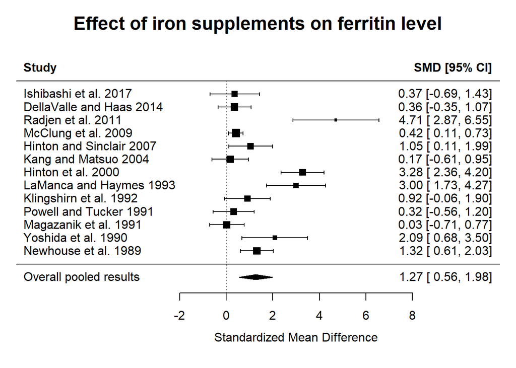

```r
# --- Make forest plot ----
forest(meta, header="Study", mlab="Overall pooled results", cex=1.0,
       main="Effect of iron supplements on ferritin level",
       cex.main = 1.5)
```

Smid et al. report an overall effect size of 1.27 (0.44, 2.10); the minor differences in the 95% confidence intervals of this estimate are likely due to implementation differences in REML estimation in `metafor` vs. SPSS.

### Semi-parametric meta-regression

Visual inspection of the effect size vs. initial ferritin level suggets a smooth, nonlinear relationship:

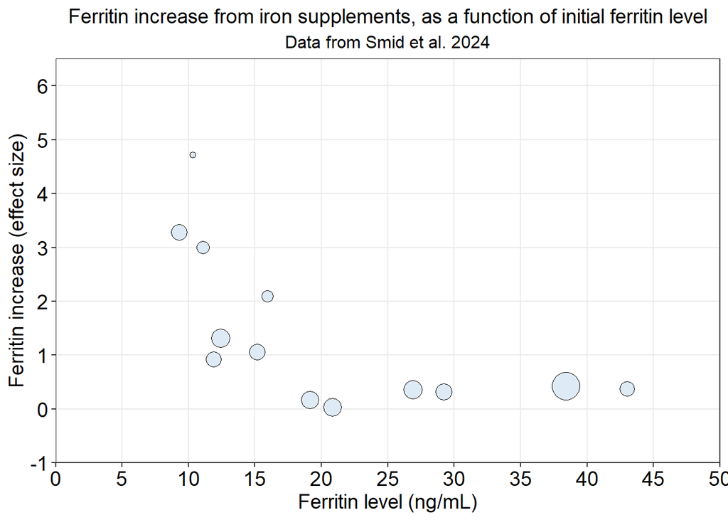

The code below implements a moderator analysis, which treats inital serum ferritin as a smooth and potentially nonlinear moderator of the effects of iron supplementation on serum ferritin increases. The effect is modeled using a cubic regression spline basis, as implemented in `mgcv` and the meta-regression package `metafor`. The analysis below follows the [official metafor tutorial documentation here.](https://www.metafor-project.org/doku.php/tips:non_linear_meta_regression) See the end of this document for a sensitivity analysis of `K`, the number of knots in the spline basis.

```r
#X-grid for plotting
xs <- seq(5, 50, length=500)

# --- Linear fit, purely for plotting purposes ---
# do note we pass sei (standard errors) here, not the default variance
# See https://www.metafor-project.org/doku.php/tips:input_to_rma_function for details
res.lin <- rma(ferritin_effect_size_smd, sei = ferritin_std_error_smd, slab=id,
               mods = ~ initial_ferritin_ng_ml,
               data = df, method="REML", measure="SMD")

# --- Smooth nonlinear meta-regression ---
# Adapted from https://www.metafor-project.org/doku.php/tips:non_linear_meta_regression

#Number of knots for spline fit, using sqrt(N) approximate rule (Harezlak et al.)
K <- 4 #See later for sensitivity analysis


#Construct a cubic spline basis in mgcv with K knots
sm <- smoothCon(s(initial_ferritin_ng_ml, bs="cr", k=K), data=df, absorb.cons=TRUE)[[1]]

#Do REML-based meta-regression, using the spline basis above as moderator
res_fer <- rma(ferritin_effect_size_smd, sei = ferritin_std_error_smd, slab=id,
               mods = ~ sm$X,
               data = df, method="REML", measure="SMD")
#Show results
res_fer
```

```
##
## Mixed-Effects Model (k = 13; tau^2 estimator: REML)
##
## tau^2 (estimated amount of residual heterogeneity):     0.0000 (SE = 0.0845)
## tau (square root of estimated tau^2 value):             0.0005
## I^2 (residual heterogeneity / unaccounted variability): 0.00%
## H^2 (unaccounted variability / sampling variability):   1.00
## R^2 (amount of heterogeneity accounted for):            100.00%
##
## Test for Residual Heterogeneity:
## QE(df = 9) = 15.6004, p-val = 0.0757
##
## Test of Moderators (coefficients 2:4):
## QM(df = 3) = 62.0554, p-val < .0001
##
## Model Results:
##
##          estimate      se     zval    pval    ci.lb    ci.ub
## intrcpt    1.1702  0.1218   9.6100  <.0001   0.9316   1.4089  ***
## sm$X1     -0.3432  0.1895  -1.8112  0.0701  -0.7145   0.0282    .
## sm$X2     -2.1858  0.3269  -6.6866  <.0001  -2.8265  -1.5451  ***
## sm$X3     -1.1806  0.3095  -3.8152  0.0001  -1.7872  -0.5741  ***
##
## ---
## Signif. codes:  0 '***' 0.001 '**' 0.01 '*' 0.05 '.' 0.1 ' ' 1
```

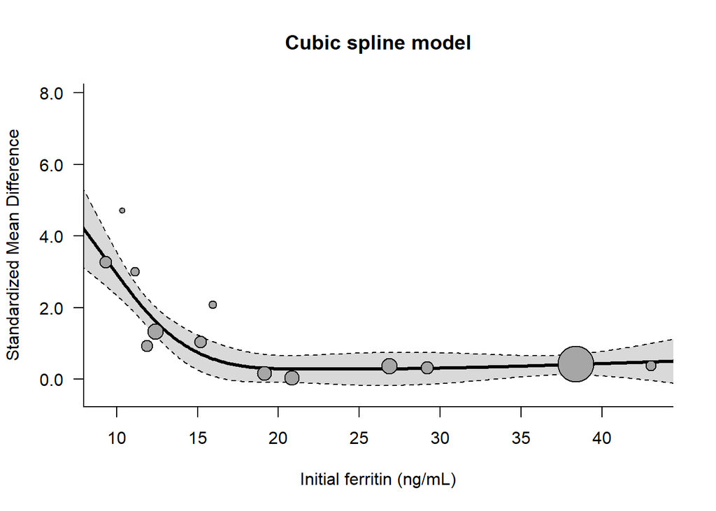

```r
#Make raw plot using metafor's base R plotting capabilities
sav <- predict(res_fer, newmods=PredictMat(sm, data.frame(initial_ferritin_ng_ml=xs)))
regplot(res.lin, mod=2, pred=sav, xvals=xs, las=1, digits=1, bty="l",
        psize=.75/df$ferritin_std_error_smd,
        xlab="Initial ferritin (ng/mL)", main="Cubic spline model")
```

Note that because of the weighting, smaller studies have less of an influence on the spline fit.

The results of the moderator analysis strongly suggest that initial ferritin level is a significant moderator of the effects of iron supplementation on serum ferritin increase (omnibus test p-value: 2.14e-13).

## Initial ferritin level and VO2max

We can also conduct a similar analysis for VO2max gains after iron supplementation. Note that only ten of the 13 studies reported VO2max data, hence the `NA` warning below.

Again, we’ll start by replicating the meta-analysis and forest plots.

```r
meta_vo2 <- rma(vo2max_effect_size, sei = vo2max_std_error, slab=id,
            data = df, method="REML", measure="SMD")
```

```
## Warning: 3 studies with NAs omitted from model fitting.
```

```r
meta_vo2
```

```
##
## Random-Effects Model (k = 10; tau^2 estimator: REML)
##
## tau^2 (estimated amount of total heterogeneity): 0.4453 (SE = 0.3022)
## tau (square root of estimated tau^2 value):      0.6673
## I^2 (total heterogeneity / total variability):   70.80%
## H^2 (total variability / sampling variability):  3.42
##
## Test for Heterogeneity:
## Q(df = 9) = 30.8264, p-val = 0.0003
##
## Model Results:
##
## estimate      se    zval    pval    ci.lb   ci.ub
##   0.4939  0.2537  1.9470  0.0515  -0.0033  0.9912  .
##
## ---
## Signif. codes:  0 '***' 0.001 '**' 0.01 '*' 0.05 '.' 0.1 ' ' 1
```

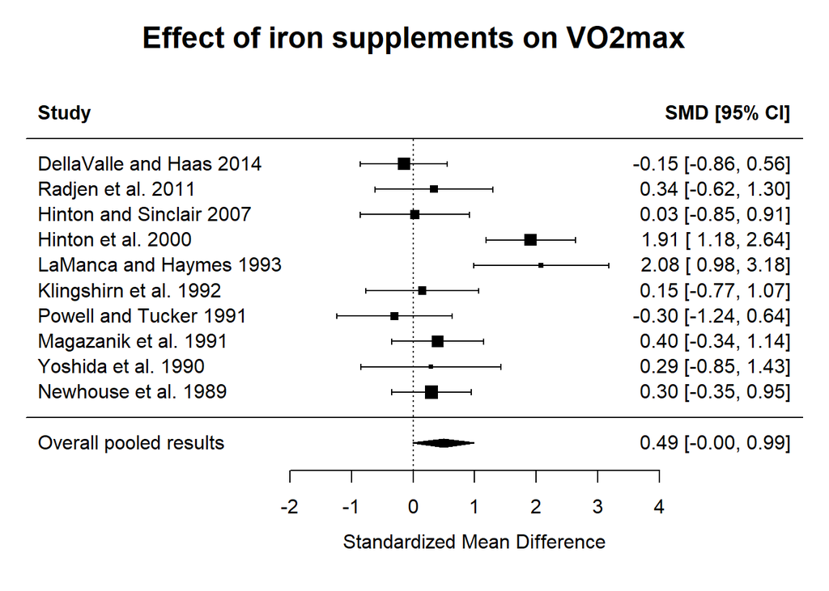

```r
# --- Make forest plot ----
forest(meta_vo2, header="Study", mlab="Overall pooled results", cex=1.0,
       main="Effect of iron supplements on VO2max",
       cex.main = 1.5)
```

Smid et al. report an overall pooled result of 0.49 (-0.08, 1.07).

### Semi-parametric meta-regression

Again, a visual inspection of the VO2max effect size vs. initial ferritin level suggets a smooth, nonlinear relationship:

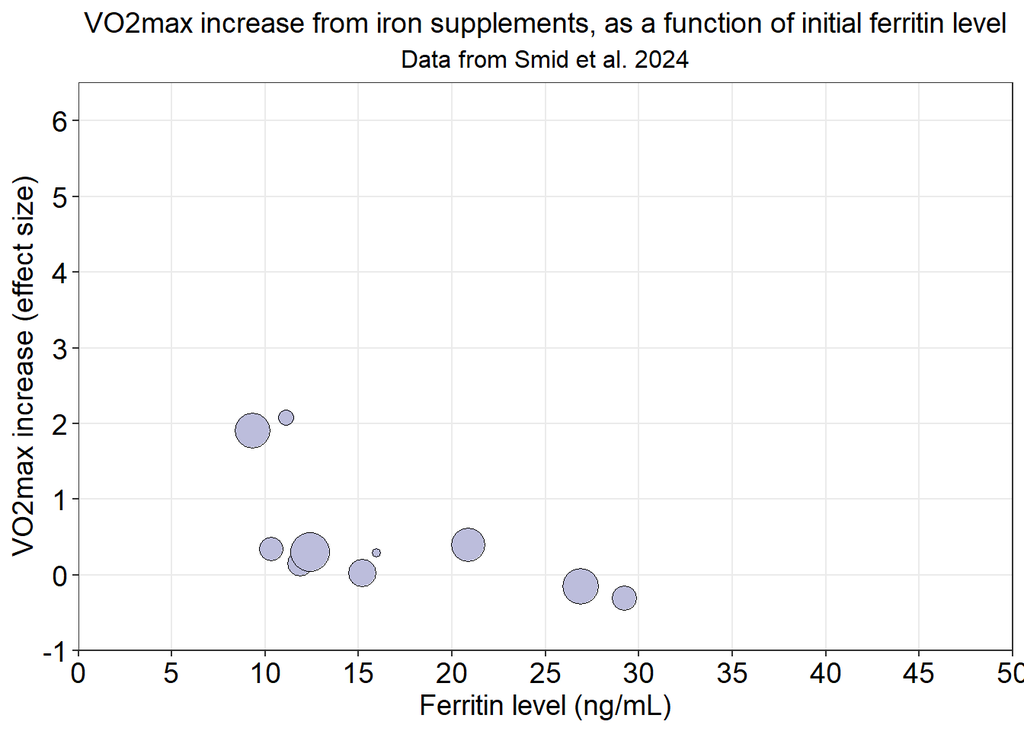

The code below implements a similar semiparametric moderator analysis as above.

```r
#Don't use all data for spline basis, just studies with VO2 measurements
df_vo2 <- df %>%
  drop_na(vo2max_effect_size)


#Plotting setup
xs_vo2 <- seq(5, 35, length=500) #no VO2 data for the higher ranges

# --- Linear fit, purely for plotting purposes ---
res.lin_vo2 <- rma(vo2max_effect_size, sei = vo2max_std_error, slab=id,
               mods = ~ initial_ferritin_ng_ml,
               data = df_vo2, method="REML", measure="SMD")

# --- Smooth nonlinear meta-regression ---

K <- 3 #Fewer studies, fewer knots
sm <- smoothCon(s(initial_ferritin_ng_ml, bs="cr", k=K), data=df_vo2, absorb.cons=TRUE)[[1]]
res_vo2 <- rma(vo2max_effect_size, sei = vo2max_std_error, slab=id,
               mods = ~ sm$X,
               data = df_vo2, method="REML", measure="SMD")
res_vo2
```

```
##
## Mixed-Effects Model (k = 10; tau^2 estimator: REML)
##
## tau^2 (estimated amount of residual heterogeneity):     0.2128 (SE = 0.2177)
## tau (square root of estimated tau^2 value):             0.4613
## I^2 (residual heterogeneity / unaccounted variability): 52.92%
## H^2 (unaccounted variability / sampling variability):   2.12
## R^2 (amount of heterogeneity accounted for):            52.21%
##
## Test for Residual Heterogeneity:
## QE(df = 7) = 14.9695, p-val = 0.0364
##
## Test of Moderators (coefficients 2:3):
## QM(df = 2) = 6.9368, p-val = 0.0312
##
## Model Results:
##
##          estimate      se     zval    pval    ci.lb   ci.ub
## intrcpt    0.4971  0.2018   2.4639  0.0137   0.1017  0.8925  *
## sm$X1     -0.6270  0.3858  -1.6249  0.1042  -1.3832  0.1293
## sm$X2     -0.7977  0.4795  -1.6637  0.0962  -1.7376  0.1421  .
##
## ---
## Signif. codes:  0 '***' 0.001 '**' 0.01 '*' 0.05 '.' 0.1 ' ' 1
```

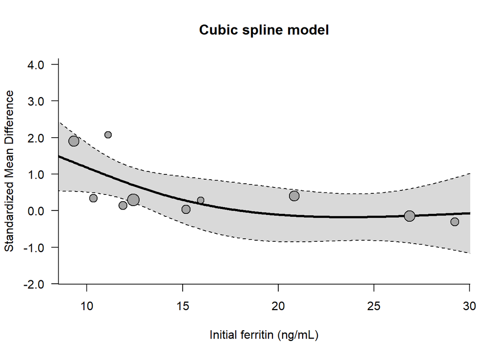

```r
sav_vo2 <- predict(res_vo2, newmods=PredictMat(sm, data.frame(initial_ferritin_ng_ml=xs_vo2)))
regplot(res.lin_vo2, mod=2, pred=sav_vo2, xvals=xs_vo2, las=1, digits=1, bty="l",
        psize=.75/df_vo2$vo2max_std_error,
        xlab="Initial ferritin (ng/mL)", main="Cubic spline model")
```

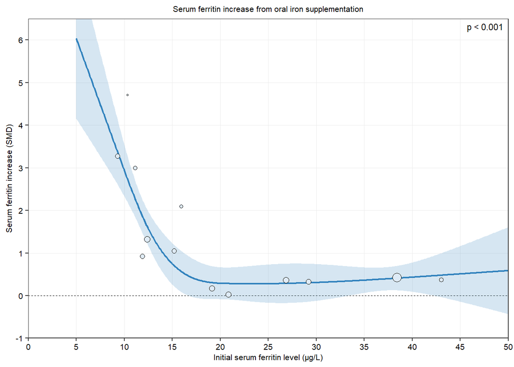

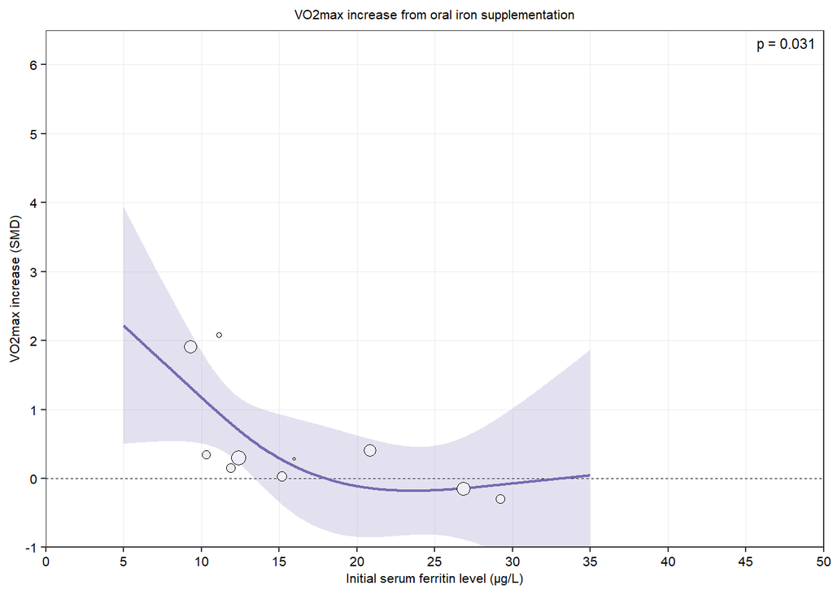

## Knot number sensitivity analysis

Assess whether choice of `K` has a strong bearing on the shape of the results.

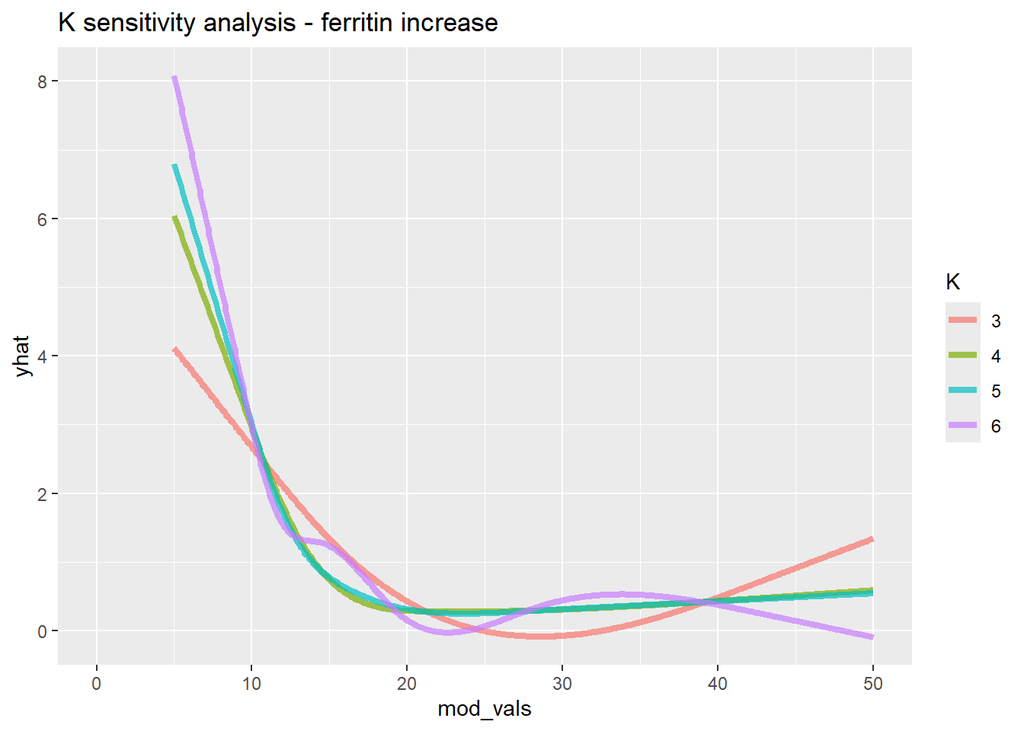

```r
#Eval grid
xs <- seq(5, 50, length=500)
K_vals <- c(3,4,5,6) #Knots to test

#Define function to use in loop
fit_mod <- function(yi, sei, mod_vals, K, xs){
  #Do semipar meta-regression, evaluate on grid, and return evaluated curve
  df_dummy <- data.frame(yi = yi,
                         sei = sei,
                         mod_vals = mod_vals)
  #Spline basis
  sm <- smoothCon(s(mod_vals, bs="cr", k=K), data=df_dummy, absorb.cons=TRUE)[[1]]

  res_spline <- rma(yi=yi, sei=sei,
                    mods = ~ sm$X,
                    data = df_dummy, method="REML", measure="SMD")
  sav_spline <- predict(res_spline, newmods=PredictMat(sm, data.frame(mod_vals=xs)))

  plot_df <- data.frame(mod_vals = xs,
                      yhat = sav_spline$pred,
                      ci_lo = sav_spline$ci.lb,
                      ci_hi = sav_spline$ci.ub,
                      K=K)
  return(plot_df)
}

# --- Ferritin increase sensitivity ---
mod_vals <- df$initial_ferritin_ng_ml
yi <- df$ferritin_effect_size_smd
sei <- df$ferritin_std_error_smd

result_list <- list()

for (i in 1:length(K_vals)){
  result_list[[i]] <- fit_mod(yi, sei, mod_vals, K_vals[i], xs)
}

ferritin_sens <- bind_rows(result_list) %>% mutate(K = factor(K))

ferritin_sens_plot <- ferritin_sens %>%
  ggplot(aes(x=mod_vals, y=yhat, color=K)) +
  geom_line(linewidth=1.5, alpha = 0.7) +
  scale_x_continuous(limits = c(0,50)) +
  ggtitle("K sensitivity analysis - ferritin increase")

ferritin_sens_plot
```

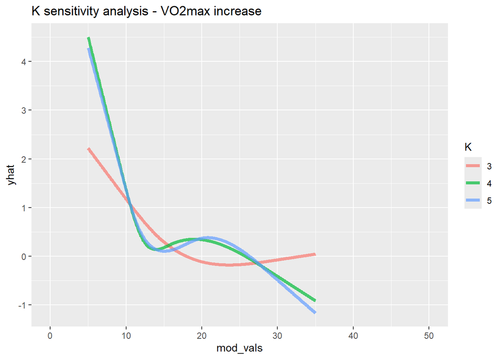

```r
# --- VO2max ---


#Eval grid
xs <- seq(5, 35, length=500)
K_vals <- c(3,4,5) #10 studies, no sense using 6 knots

#Data
mod_vals <- df_vo2$initial_ferritin_ng_ml
yi <- df_vo2$vo2max_effect_size
sei <- df_vo2$vo2max_std_error

result_list <- list()

for (i in 1:length(K_vals)){
  result_list[[i]] <- fit_mod(yi, sei, mod_vals, K_vals[i], xs)
}

vo2_sens <- bind_rows(result_list) %>% mutate(K = factor(K))

vo2_sens_plot <- vo2_sens %>%
  ggplot(aes(x=mod_vals, y=yhat, color=K)) +
  geom_line(linewidth=1.5, alpha = 0.7) +
  scale_x_continuous(limits = c(0,50)) +
  ggtitle("K sensitivity analysis - VO2max increase")

vo2_sens_plot
```

For increased serum ferritin, the choice of K does not have a particularly strong effect on the results in the 10-25 ng/mL range. `K=3` is likely too small, given its less-plausible U-shaped curve.

For increased VO2max, the choice of K has a modest effect on estimated benefits of iron supplementation in the 10-25 ng/mL range. All three choices still show a definite increase in VO2max at low levels of ferritin, with the “wiggles” near 15 ng/mL for `K=4` and `K=5` likely attributable to the dearth of studies with initial ferrtin levels of 17-25 ng/mL.